# MovieLens Project Questions [Arivu]

### `Project - MovieLens Data Analysis`

The GroupLens Research Project is a research group in the Department of Computer Science and Engineering at the University of Minnesota. The data is widely used for collaborative filtering and other filtering solutions. However, we will be using this data to act as a means to demonstrate our skill in using Python to “play” with data.

### `Objective:`

- To implement the techniques learnt as a part of the course.

### `Learning Outcomes:`

- Exploratory Data Analysis
- Visualization using Python
- Pandas – groupby, merging

### `Domain`

- Internet and Entertainment

**Note that the project will need you to apply the concepts of groupby and merging extensively.**

### `Datasets Information:`

*rating.csv:* It contains information on ratings given by the users to a particular movie.

- user id: id assigned to every user
- movie id: id assigned to every movie
- rating: rating given by the user
- timestamp: Time recorded when the user gave a rating

*movie.csv:* File contains information related to the movies and their genre.

- movie id: id assigned to every movie
- movie title: Title of the movie
- release date: Date of release of the movie
- Action: Genre containing binary values (1 - for action 0 - not action)
- Adventure: Genre containing binary values (1 - for adventure 0 - not adventure)
- Animation: Genre containing binary values (1 - for animation 0 - not animation)
- Children’s: Genre containing binary values (1 - for children's 0 - not children's)
- Comedy: Genre containing binary values (1 - for comedy 0 - not comedy)
- Crime: Genre containing binary values (1 - for crime 0 - not crime)
- Documentary: Genre containing binary values (1 - for documentary 0 - not documentary)
- Drama: Genre containing binary values (1 - for drama 0 - not drama)
- Fantasy: Genre containing binary values (1 - for fantasy 0 - not fantasy)
- Film-Noir: Genre containing binary values (1 - for film-noir 0 - not film-noir)
- Horror: Genre containing binary values (1 - for horror 0 - not horror)
- Musical: Genre containing binary values (1 - for musical 0 - not musical)
- Mystery: Genre containing binary values (1 - for mystery 0 - not mystery)
- Romance: Genre containing binary values (1 - for romance 0 - not romance)
- Sci-Fi: Genre containing binary values (1 - for sci-fi 0 - not sci-fi)
- Thriller: Genre containing binary values (1 - for thriller 0 - not thriller)
- War: Genre containing binary values (1 - for war 0 - not war)
- Western: Genre containing binary values (1 - for western - not western)

*user.csv:* It contains information of the users who have rated the movies.

- user id: id assigned to every user
- age: Age of the user
- gender: Gender of the user
- occupation: Occupation of the user
- zip code: Zip code of the use

**`Please provide you insights wherever necessary.`**

### 1. Import the necessary packages - 2.5 marks

```python
#importing the necessary packages

import numpy as np
import pandas as pd
import matplotlib.pyplot as plt
import seaborn as sns

sns.set(color_codes = True)
%matplotlib inline
```

### 2. Read the 3 datasets into dataframes - 2.5 marks

```python
user_df= pd.read_csv("user.csv")
movie_df = pd.read_csv("item.csv")
rating_df = pd.read_csv("Data.csv")
```

### 3. Apply info, shape, describe, and find the number of missing values in the data - 5 marks

- Note that you will need to do it for all the three datasets seperately

```python
print ("-------------------------------------------------------")
print ("user_df Dataframe ")
print ("-------------------------------------------------------")
print ("Info")
print (user_df.info())
print ("-------------------------------------------------------")
print ("Shape")
print (user_df.shape)
print ("-------------------------------------------------------")
print ("Describe")
print ( user_df.describe())
print ("-------------------------------------------------------")
print ("Number of missing values by columns")
print (user_df.isnull().sum())
```

```
-------------------------------------------------------
user_df Dataframe
-------------------------------------------------------
Info
<class 'pandas.core.frame.DataFrame'>
RangeIndex: 943 entries, 0 to 942
Data columns (total 5 columns):
 #   Column      Non-Null Count  Dtype
---  ------      --------------  -----
 0   user id     943 non-null    int64
 1   age         943 non-null    int64
 2   gender      943 non-null    object
 3   occupation  943 non-null    object
 4   zip code    943 non-null    object
dtypes: int64(2), object(3)
memory usage: 37.0+ KB
None
-------------------------------------------------------
Shape
(943, 5)
-------------------------------------------------------
Describe
          user id         age
count  943.000000  943.000000
mean   472.000000   34.051962
std    272.364951   12.192740
min      1.000000    7.000000
25%    236.500000   25.000000
50%    472.000000   31.000000
75%    707.500000   43.000000
max    943.000000   73.000000
-------------------------------------------------------
Number of missing values by columns
user id       0
age           0
gender        0
occupation    0
zip code      0
dtype: int64
```

```python
print ("-------------------------------------------------------")
print ("movie_df Dataframe ")
print ("-------------------------------------------------------")
print ("Info")
print (movie_df.info())
print ("-------------------------------------------------------")
print ("Shape")
print (movie_df.shape)
print ("-------------------------------------------------------")
print ("Describe")
print ( movie_df.describe())
print ("-------------------------------------------------------")
print ("Number of missing values by columns")
print (movie_df.isnull().sum())
```

```
-------------------------------------------------------
movie_df Dataframe
-------------------------------------------------------
Info
<class 'pandas.core.frame.DataFrame'>
RangeIndex: 1681 entries, 0 to 1680
Data columns (total 22 columns):
 #   Column        Non-Null Count  Dtype
---  ------        --------------  -----
 0   movie id      1681 non-null   int64
 1   movie title   1681 non-null   object
 2   release date  1681 non-null   object
 3   unknown       1681 non-null   int64
 4   Action        1681 non-null   int64
 5   Adventure     1681 non-null   int64
 6   Animation     1681 non-null   int64
 7   Childrens     1681 non-null   int64
 8   Comedy        1681 non-null   int64
 9   Crime         1681 non-null   int64
 10  Documentary   1681 non-null   int64
 11  Drama         1681 non-null   int64
 12  Fantasy       1681 non-null   int64
 13  Film-Noir     1681 non-null   int64
 14  Horror        1681 non-null   int64
 15  Musical       1681 non-null   int64
 16  Mystery       1681 non-null   int64
 17  Romance       1681 non-null   int64
 18  Sci-Fi        1681 non-null   int64
 19  Thriller      1681 non-null   int64
 20  War           1681 non-null   int64
 21  Western       1681 non-null   int64
dtypes: int64(20), object(2)
memory usage: 289.0+ KB
None
-------------------------------------------------------
Shape
(1681, 22)
-------------------------------------------------------
Describe
          movie id      unknown       Action    Adventure    Animation  \
```

[output cut: 48 more lines]

```
Comedy          0
Crime           0
Documentary     0
Drama           0
Fantasy         0
Film-Noir       0
Horror          0
Musical         0
Mystery         0
Romance         0
Sci-Fi          0
Thriller        0
War             0
Western         0
dtype: int64
```

```python
print ("-------------------------------------------------------")
print ("rating_df Dataframe ")
print ("-------------------------------------------------------")
print ("Info")
print (rating_df.info())
print ("-------------------------------------------------------")
print ("Shape")
print (rating_df.shape)
print ("-------------------------------------------------------")
print ("Describe")
print ( rating_df.describe())
print ("-------------------------------------------------------")
print ("Number of missing values by columns")
print (rating_df.isnull().sum())
```

```
-------------------------------------------------------
rating_df Dataframe
-------------------------------------------------------
Info
<class 'pandas.core.frame.DataFrame'>
RangeIndex: 100000 entries, 0 to 99999
Data columns (total 4 columns):
 #   Column     Non-Null Count   Dtype
---  ------     --------------   -----
 0   user id    100000 non-null  int64
 1   movie id   100000 non-null  int64
 2   rating     100000 non-null  int64
 3   timestamp  100000 non-null  int64
dtypes: int64(4)
memory usage: 3.1 MB
None
-------------------------------------------------------
Shape
(100000, 4)
-------------------------------------------------------
Describe
            user id       movie id         rating     timestamp
count  100000.00000  100000.000000  100000.000000  1.000000e+05
mean      462.48475     425.530130       3.529860  8.835289e+08
std       266.61442     330.798356       1.125674  5.343856e+06
min         1.00000       1.000000       1.000000  8.747247e+08
25%       254.00000     175.000000       3.000000  8.794487e+08
50%       447.00000     322.000000       4.000000  8.828269e+08
75%       682.00000     631.000000       4.000000  8.882600e+08
max       943.00000    1682.000000       5.000000  8.932866e+08
-------------------------------------------------------
Number of missing values by columns
user id      0
movie id     0
rating       0
timestamp    0
dtype: int64
```

### 4. Find the number of movies per genre using the item data - 2.5 marks

```python
# using duplicated to remove duplicates
# And then columns are summed up to answer this question

dedup_movie_df=movie_df[movie_df.duplicated(subset=["movie title","release date"],keep='first')==False]
dedup_movie_df.sum()[3:]
```

```
unknown          1
Action         249
Adventure      133
Animation       42
Childrens      120
Comedy         502
Crime          107
Documentary     50
Drama          716
Fantasy         22
Film-Noir       24
Horror          90
Musical         56
Mystery         60
Romance        244
Sci-Fi         100
Thriller       248
War             71
Western         27
dtype: object
```

### 5. Drop the movie where the genre is unknown - 2.5 marks

```python
dedup_movie_df[dedup_movie_df["unknown"]==1] # Filtering the rows where unknown==1
```

|  | movie id | movie title | release date | unknown | Action | Adventure | Animation | Childrens | Comedy | Crime | ... | Fantasy | Film-Noir | Horror | Musical | Mystery | Romance | Sci-Fi | Thriller | War | Western |
| --- | --- | --- | --- | --- | --- | --- | --- | --- | --- | --- | --- | --- | --- | --- | --- | --- | --- | --- | --- | --- | --- |
| 1371 | 1373 | Good Morning | 4-Feb-1971 | 1 | 0 | 0 | 0 | 0 | 0 | 0 | ... | 0 | 0 | 0 | 0 | 0 | 0 | 0 | 0 | 0 | 0 |

1 rows × 22 columns

```python
# Dropping from the dataframe with the index of unknown rows
unknown_dropped_dedup_movie_df= dedup_movie_df.drop(dedup_movie_df[dedup_movie_df["unknown"]==1].index)

#checking the rows in all dataframes and makes sure rows are dropped
print (movie_df.shape)
print (dedup_movie_df.shape)
print (unknown_dropped_dedup_movie_df.shape)
```

```
(1681, 22)
(1663, 22)
(1662, 22)
```

### 6. Find the movies that have more than one genre - 5 marks

hint: use sum on the axis = 1

Display movie name, number of genres for the movie in dataframe

and also print(total number of movies which have more than one genres)

```python
# adding a column to dataframe number_of_genres (summing the rows of all genre columb)
dedup_movie_df ["number_of_genres"]= dedup_movie_df[[  'unknown', 'Action',
       'Adventure', 'Animation', 'Childrens', 'Comedy', 'Crime', 'Documentary',
       'Drama', 'Fantasy', 'Film-Noir', 'Horror', 'Musical', 'Mystery',
       'Romance', 'Sci-Fi', 'Thriller', 'War', 'Western']].sum(axis=1)
```

```python
# Total number of movies with more than 1 genere
dedup_movie_df[dedup_movie_df['number_of_genres']>1]["movie title"].count()
```

```
840
```

```python
# prnting the movie title with more than 1 genres
dedup_movie_df[dedup_movie_df['number_of_genres']>1][["movie title","number_of_genres"]]
```

|  | movie title | number_of_genres |
| --- | --- | --- |
| 0 | Toy Story | 3 |
| 1 | GoldenEye | 3 |
| 3 | Get Shorty | 3 |
| 4 | Copycat | 3 |
| 6 | Twelve Monkeys | 2 |
| ... | ... | ... |
| 1661 | Nothing Personal | 2 |
| 1667 | MURDER and murder | 3 |
| 1668 | Tainted | 2 |
| 1671 | Mirage | 2 |
| 1677 | B. Monkey | 2 |

840 rows × 2 columns

### 7. Univariate plots of columns: 'rating', 'Age', 'release year', 'Gender' and 'Occupation' - 10 marks

*HINT: Use distplot for age. Use lineplot or countplot for release year.*

*HINT: Plot percentages in y-axis and categories in x-axis for ratings, gender and occupation*

*HINT: Please refer to the below snippet to understand how to get to release year from release date. You can use str.split() as depicted below or you could convert it to pandas datetime format and extract year (.dt.year)*

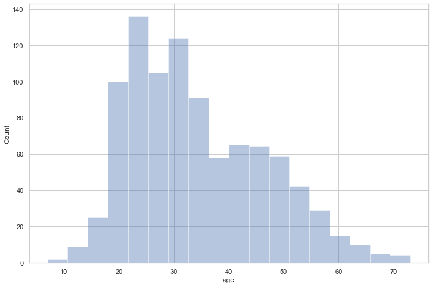

```python
# Univariate plot of Age

sns.set_style("whitegrid")
fig_dims = (12, 8)
fig, ax = plt.subplots(figsize=fig_dims)
ax.set(xlabel="Age", ylabel = "Count")

sns.distplot(user_df["age"],ax=ax,kde=False)
```

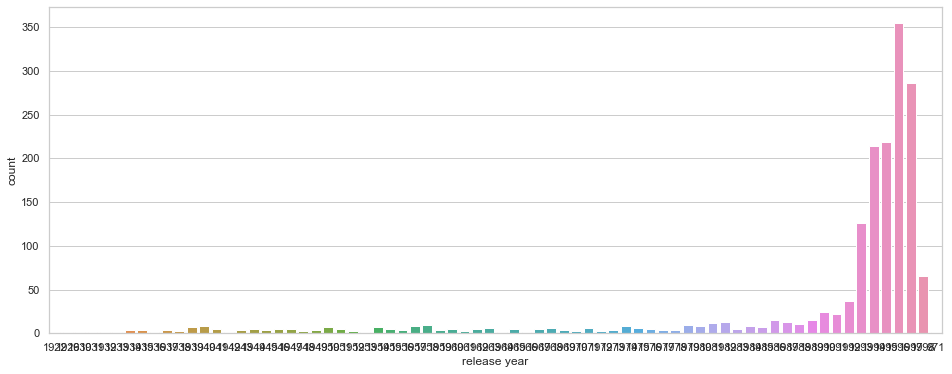

```python
# Univariate plot of Release year


movie_df["release year"]=movie_df["release date"].str[7:]

sns.set_style("whitegrid")
fig_dims = (16, 6)
fig, ax = plt.subplots(figsize=fig_dims)
ax.set(xlabel="Release Year", ylabel = "Count")

sns.countplot(x=movie_df["release year"])
```

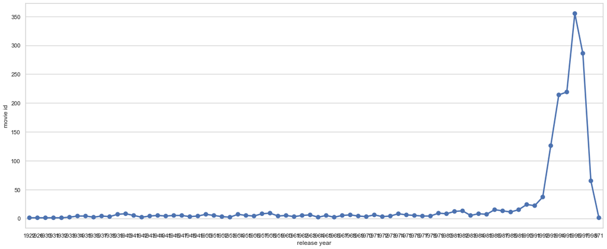

```python
sns.set_style("whitegrid")
fig_dims = (20, 8)
fig, ax = plt.subplots(figsize=fig_dims)
ax.set(xlabel="Release Year", ylabel = "Count")

sns.pointplot (x=movie_df_group.index, y=movie_df_group["movie id"])
```

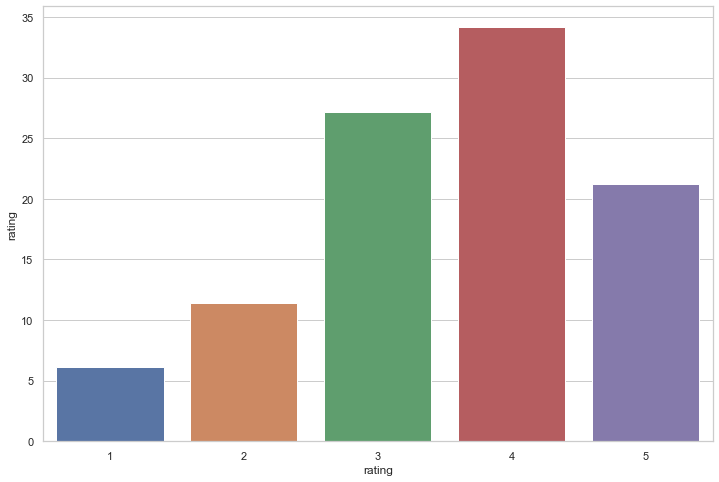

```python
# Univariate plot of rating


sns.set_style("whitegrid")
fig_dims = (12, 8)
fig, ax = plt.subplots(figsize=fig_dims)
ax.set(xlabel="Rating", ylabel = "Percent")


sns.barplot(x="rating", y="rating", data=rating_df, estimator=lambda x: len(x) / len(rating_df) * 100)
```

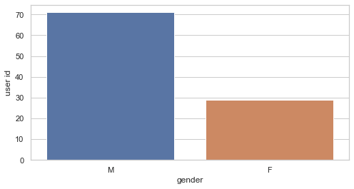

```python
# Univariate plot of gender


sns.set_style("whitegrid")
fig_dims = (8, 4)
fig, ax = plt.subplots(figsize=fig_dims)
ax.set(xlabel="Gender", ylabel = "Percent")


sns.barplot(x="gender", y="user id", data=user_df, estimator=lambda x: len(x) / len(user_df) * 100)
```

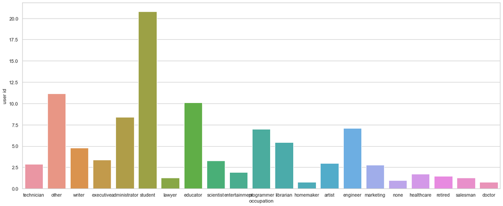

```python
# Univariate plot of occupation

sns.set_style("whitegrid")
fig_dims = (20, 8)
fig, ax = plt.subplots(figsize=fig_dims)
ax.set(xlabel="Occupation", ylabel = "Percent")

sns.barplot(x="occupation", y="user id", data=user_df, estimator=lambda x: len(x) / len(user_df) * 100)
```

```python
a = 'My*cat*is*brown'
print(a.split('*')[3])

#similarly, the release year needs to be taken out from release date

#also you can simply slice existing string to get the desired data, if we want to take out the colour of the cat

print(a[10:])
print(a[-5:])
```

```
brown
brown
brown
```

### 8. Visualize how popularity of genres has changed over the years - 10 marks

Note that you need to use the **percent of number of releases in a year** as a parameter of popularity of a genre

Hint 1: You need to reach to a data frame where the release year is the index and the genre is the column names (one cell shows the number of release in a year in one genre) or vice versa. (Drop unnecessary column if there are any)

Hint 2: Find the total number of movies release in a year(use `sum(axis=1)` store that value in a new column as 'total'). Now divide the value of each genre in that year by total to get percentage number of release in a particular year. `(df.div(df['total'], axis= 0) * 100)`

Once that is achieved, you can either use univariate plots or can use the heatmap to visualise all the changes over the years in one go.

Hint 3: Use groupby on the relevant column and use sum() on the same to find out the number of releases in a year/genre.

```python
# Dropping the movie id and movie title columns and keep only genres
dedup_movie_df.drop(columns=['movie id','movie title'], inplace=True)


# converting the release date to release yer
dedup_movie_df["release year"]=dedup_movie_df["release date"].str[7:]
```

```python
# Checking the dataframe
dedup_movie_df.head()
```

|  | release date | unknown | Action | Adventure | Animation | Childrens | Comedy | Crime | Documentary | Drama | ... | Film-Noir | Horror | Musical | Mystery | Romance | Sci-Fi | Thriller | War | Western | release year |
| --- | --- | --- | --- | --- | --- | --- | --- | --- | --- | --- | --- | --- | --- | --- | --- | --- | --- | --- | --- | --- | --- |
| 0 | 01-Jan-1995 | 0 | 0 | 0 | 1 | 1 | 1 | 0 | 0 | 0 | ... | 0 | 0 | 0 | 0 | 0 | 0 | 0 | 0 | 0 | 1995 |
| 1 | 01-Jan-1995 | 0 | 1 | 1 | 0 | 0 | 0 | 0 | 0 | 0 | ... | 0 | 0 | 0 | 0 | 0 | 0 | 1 | 0 | 0 | 1995 |
| 2 | 01-Jan-1995 | 0 | 0 | 0 | 0 | 0 | 0 | 0 | 0 | 0 | ... | 0 | 0 | 0 | 0 | 0 | 0 | 1 | 0 | 0 | 1995 |
| 3 | 01-Jan-1995 | 0 | 1 | 0 | 0 | 0 | 1 | 0 | 0 | 1 | ... | 0 | 0 | 0 | 0 | 0 | 0 | 0 | 0 | 0 | 1995 |
| 4 | 01-Jan-1995 | 0 | 0 | 0 | 0 | 0 | 0 | 1 | 0 | 1 | ... | 0 | 0 | 0 | 0 | 0 | 0 | 1 | 0 | 0 | 1995 |

5 rows × 21 columns

```python
# Dropping the release date column
dedup_movie_df.drop(columns=['release date'],inplace=True)

# Grouping by year
year_agg_df = dedup_movie_df.groupby ("release year").sum().sort_index(ascending=True)

# Dropping an invalid year record
year_agg_df.drop('971',inplace=True)

year_agg_df
```

| release year | unknown | Action | Adventure | Animation | Childrens | Comedy | Crime | Documentary | Drama | Fantasy | Film-Noir | Horror | Musical | Mystery | Romance | Sci-Fi | Thriller | War | Western |
| --- | --- | --- | --- | --- | --- | --- | --- | --- | --- | --- | --- | --- | --- | --- | --- | --- | --- | --- | --- |
| 1922 | 0 | 0 | 0 | 0 | 0 | 0 | 0 | 0 | 0 | 0 | 0 | 1 | 0 | 0 | 0 | 0 | 0 | 0 | 0 |
| 1926 | 0 | 0 | 0 | 0 | 0 | 0 | 0 | 0 | 1 | 0 | 0 | 0 | 0 | 0 | 0 | 0 | 0 | 0 | 0 |
| 1930 | 0 | 0 | 0 | 0 | 0 | 0 | 0 | 0 | 1 | 0 | 0 | 0 | 0 | 0 | 0 | 0 | 0 | 0 | 0 |
| 1931 | 0 | 0 | 0 | 0 | 0 | 0 | 1 | 0 | 0 | 0 | 1 | 0 | 0 | 0 | 0 | 0 | 1 | 0 | 0 |
| 1932 | 0 | 0 | 0 | 0 | 0 | 0 | 0 | 0 | 0 | 0 | 0 | 0 | 0 | 0 | 1 | 0 | 0 | 1 | 0 |
| ... | ... | ... | ... | ... | ... | ... | ... | ... | ... | ... | ... | ... | ... | ... | ... | ... | ... | ... | ... |
| 1994 | 0 | 30 | 13 | 4 | 15 | 82 | 8 | 9 | 97 | 3 | 0 | 8 | 2 | 2 | 35 | 7 | 25 | 7 | 6 |
| 1995 | 0 | 40 | 22 | 6 | 21 | 63 | 11 | 5 | 89 | 3 | 1 | 14 | 3 | 5 | 37 | 15 | 39 | 5 | 2 |
| 1996 | 0 | 44 | 23 | 9 | 20 | 108 | 21 | 18 | 169 | 6 | 1 | 11 | 9 | 6 | 38 | 15 | 47 | 9 | 2 |
| 1997 | 0 | 44 | 19 | 3 | 21 | 85 | 29 | 6 | 109 | 4 | 2 | 7 | 5 | 17 | 49 | 13 | 53 | 14 | 0 |
| 1998 | 0 | 12 | 3 | 0 | 1 | 12 | 6 | 3 | 29 | 1 | 2 | 4 | 1 | 3 | 10 | 5 | 17 | 0 | 0 |

71 rows × 19 columns

```python
# Adding percent distribution to the dataframe
final_year_agg_df=year_agg_df.div(year_agg_df.sum(axis=1), axis=0)

final_year_agg_df.head()
```

| release year | unknown | Action | Adventure | Animation | Childrens | Comedy | Crime | Documentary | Drama | Fantasy | Film-Noir | Horror | Musical | Mystery | Romance | Sci-Fi | Thriller | War | Western |
| --- | --- | --- | --- | --- | --- | --- | --- | --- | --- | --- | --- | --- | --- | --- | --- | --- | --- | --- | --- |
| 1922 | 0.0 | 0.0 | 0.0 | 0.0 | 0.0 | 0.0 | 0.000000 | 0.0 | 0.0 | 0.0 | 0.000000 | 1.0 | 0.0 | 0.0 | 0.0 | 0.0 | 0.000000 | 0.0 | 0.0 |
| 1926 | 0.0 | 0.0 | 0.0 | 0.0 | 0.0 | 0.0 | 0.000000 | 0.0 | 1.0 | 0.0 | 0.000000 | 0.0 | 0.0 | 0.0 | 0.0 | 0.0 | 0.000000 | 0.0 | 0.0 |
| 1930 | 0.0 | 0.0 | 0.0 | 0.0 | 0.0 | 0.0 | 0.000000 | 0.0 | 1.0 | 0.0 | 0.000000 | 0.0 | 0.0 | 0.0 | 0.0 | 0.0 | 0.000000 | 0.0 | 0.0 |
| 1931 | 0.0 | 0.0 | 0.0 | 0.0 | 0.0 | 0.0 | 0.333333 | 0.0 | 0.0 | 0.0 | 0.333333 | 0.0 | 0.0 | 0.0 | 0.0 | 0.0 | 0.333333 | 0.0 | 0.0 |
| 1932 | 0.0 | 0.0 | 0.0 | 0.0 | 0.0 | 0.0 | 0.000000 | 0.0 | 0.0 | 0.0 | 0.000000 | 0.0 | 0.0 | 0.0 | 0.5 | 0.0 | 0.000000 | 0.5 | 0.0 |

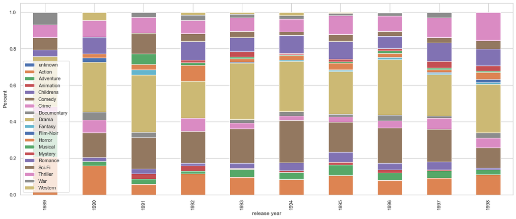

```python
# Plotting only the recent 10 years to answer the question

sns.set_style("whitegrid")
fig_dims = (20, 8)
fig, ax = plt.subplots(figsize=fig_dims)
ax.set(xlabel="Release Year", ylabel = "Percent")

final_year_agg_df.tail(10).plot(kind='bar',stacked=True,ax=ax)
```

### 9. Find the top 25 movies according to average ratings such that each movie has number of ratings more than 100 - 10 marks

Hints :

1. Find the count of ratings and average ratings for every movie.
2. Slice the movies which have ratings more than 100.
3. Sort values according to average rating such that movie which highest rating is on top.
4. Select top 25 movies.
5. You will have to use the .merge() function to get the movie titles.

Note: This question will need you to research about groupby and apply your findings. You can find more on groupby on https://realpython.com/pandas-groupby/.

```python
# grouping movie_df by movie id and adding all counts
movie_agg_df=rating_df.groupby("movie id").count()


# grouping movie_df by movie id and adding all sums
movie_agg_df["rating_sum"]=rating_df.groupby("movie id").rating.sum()
movie_agg_df
```

| movie id | user id | rating | timestamp | rating_sum |
| --- | --- | --- | --- | --- |
| 1 | 452 | 452 | 452 | 1753 |
| 2 | 131 | 131 | 131 | 420 |
| 3 | 90 | 90 | 90 | 273 |
| 4 | 209 | 209 | 209 | 742 |
| 5 | 86 | 86 | 86 | 284 |
| ... | ... | ... | ... | ... |
| 1678 | 1 | 1 | 1 | 1 |
| 1679 | 1 | 1 | 1 | 3 |
| 1680 | 1 | 1 | 1 | 2 |
| 1681 | 1 | 1 | 1 | 3 |
| 1682 | 1 | 1 | 1 | 3 |

1682 rows × 4 columns

```python
# Filtering only the movies with 100+ ratings and storing them in top_movie_agg dataframe
top_movie_agg=movie_agg_df[movie_agg_df["rating"]>=100]

# Adding avg rating as column to the same dataframe
top_movie_agg["avg_rating"]=top_movie_agg["rating_sum"]*1.00/top_movie_agg["rating"]*1.00

# sorting by avg rating and filtering only the top 25 and storing them in a separate dataframe top25_movie_agg
top25_movie_agg=top_movie_agg.sort_values(by="avg_rating",ascending = False).head(25)
```

```python
# Prepping the movie_df for joining and setting the movie id as index for easier join on movie id
movie_df_lookup=movie_df[["movie id","movie title"]]
movie_df_lookup.index = movie_df_lookup["movie id"]

# Joining the Top 25 movie avg rating with movie_df for the final report
Final_TOP25_Report=top25_movie_agg.join (movie_df_lookup,how="left")[["movie title", "avg_rating"]]

Final_TOP25_Report.reset_index()
```

|  | movie id | movie title | avg_rating |
| --- | --- | --- | --- |
| 0 | 408 | Close Shave, A | 4.491071 |
| 1 | 318 | Schindler's List | 4.466443 |
| 2 | 169 | Wrong Trousers, The | 4.466102 |
| 3 | 483 | Casablanca | 4.456790 |
| 4 | 64 | Shawshank Redemption, The | 4.445230 |
| 5 | 603 | Rear Window | 4.387560 |
| 6 | 12 | Usual Suspects, The | 4.385768 |
| 7 | 50 | Star Wars | 4.358491 |
| 8 | 178 | 12 Angry Men | 4.344000 |
| 9 | 134 | Citizen Kane | 4.292929 |
| 10 | 427 | To Kill a Mockingbird | 4.292237 |
| 11 | 357 | One Flew Over the Cuckoo's Nest | 4.291667 |
| 12 | 98 | Silence of the Lambs, The | 4.289744 |
| 13 | 480 | North by Northwest | 4.284916 |
| 14 | 127 | Godfather, The | 4.283293 |
| 15 | 285 | Secrets & Lies | 4.265432 |
| 16 | 272 | Good Will Hunting | 4.262626 |
| 17 | 657 | Manchurian Candidate, The | 4.259542 |
| 18 | 474 | Dr. Strangelove or: How I Learned to Stop Worr... | 4.252577 |
| 19 | 174 | Raiders of the Lost Ark | 4.252381 |
| 20 | 479 | Vertigo | 4.251397 |
| 21 | 313 | Titanic | 4.245714 |
| 22 | 511 | Lawrence of Arabia | 4.231214 |
| 23 | 484 | Maltese Falcon, The | 4.210145 |
| 24 | 172 | Empire Strikes Back, The | 4.204360 |

### 10. See gender distribution across different genres check for the validity of the below statements - 10 marks

- Men watch more drama than women
- Women watch more Sci-Fi than men
- Men watch more Romance than women

**compare the percentages**

1. Merge all the datasets
2. There is no need to conduct statistical tests around this. Just **compare the percentages** and comment on the validity of the above statements.
3. you might want ot use the .sum(), .div() function here.
4. Use number of ratings to validate the numbers. For example, if out of 4000 ratings received by women, 3000 are for drama, we will assume that 75% of the women watch drama.

```python
# As user id is the joining column on user_df, this is to check if user id is unique on the joining table
print (user_df["user id"].nunique())
print (user_df["user id"].count())

# As movie id is the joining column on movie_df, this is to check if movie id is is unique on the joining table
print (movie_df["movie id"].nunique())
print (movie_df["movie id"].count())


#rating_df left join with user_df on user id to get gender
rating_gender_df=pd.merge(rating_df, user_df[["user id","gender"]], on="user id", how="left")


#Prepping the movie_df for this analysis

#Adding a column called total to sum up all genres at row level
movie_df['total']=movie_df.iloc[:, 2:].sum(axis=1) # to exclude index and first 2 columns in row sum

#Adding a column called other to sum up all non (drama/sci-fi/romance) at row leve=l
movie_df["other"] = movie_df["total"]- (movie_df["Drama"]+movie_df["Sci-Fi"]+movie_df["Romance"])


#rating_gender_df left join with movie df to get all genres counts
rating_gender_movie_df=pd.merge(rating_gender_df,movie_df [['movie id','Drama','Sci-Fi','Romance','other','total']]
                                , on="movie id", how="left")


# grouping by gender and summing up all genres
gender_groupby=rating_gender_movie_df.groupby ("gender").sum()


# Addding Percentage numbers
gender_groupby["Sci-Fi perc"]=gender_groupby["Sci-Fi"]/gender_groupby["total"]
gender_groupby["Drama perc"]=gender_groupby["Drama"]/gender_groupby["total"]
gender_groupby["Romance perc"]=gender_groupby["Romance"]/gender_groupby["total"]
```

```
943
943
1681
1681
```

```python
gender_groupby
```

| gender | user id | movie id | rating | timestamp | Drama | Sci-Fi | Romance | other | total | Sci-Fi perc | Drama perc | Romance perc |
| --- | --- | --- | --- | --- | --- | --- | --- | --- | --- | --- | --- | --- |
| F | 12226134 | 11453179 | 90901 | 22750324303258 | 11008.0 | 2629.0 | 5858.0 | 34206.0 | 53701.0 | 0.048956 | 0.204987 | 0.109085 |
| M | 34022341 | 31099834 | 262085 | 65602560845604 | 28887.0 | 10101.0 | 13603.0 | 106294.0 | 158885.0 | 0.063574 | 0.181811 | 0.085615 |

# Looking at the above dataframe, below questions can be answered Men watch more drama than women - False Women watch more Sci-Fi than men - False Men watch more Romance than women - False